# H2o Generalized Linear Model

> [R code](https://github.com/ethen8181/machine-learning/blob/master/h2o/h2o_glm/h2o_glm.R) to the documentation for those that wish to follow along.

# Basic Background Information

The strength of Generalized Linear Models are that they are easy to fit; easy to understand. Though it does not deal very well with correlated variables, thus, often times you need to add L1 (Lasso) or L2 (Ridge) regularization or so called penalty, which is controlled by the `alpha` and `lambda` value to prevent overfitting.

- `alpha` A value of 1.0 for `alpha` represents Lasso, and a value of 0.0 produces Ridge regression.
- `lambda` This is the most important piece of information for someone learning about regularization. It controls how complex the model is allowed to be. The intuition is: when lambda is large, you penalize your model very heavily when it starts to get more complex, on the opposite when the value is 0, you don’t penalize it at all and the `alpha` parameter is ignored.

In h2o you can specify to use a `lambda_search` = TRUE. Lambda search enables efficient and automatic search for the optimal value of the lambda parameter. When lambda search is enabled, GLM will first fit a model with maximum regularization and then keep decreasing it until overfitting occurs (If running lambda search with a validation dataset, the chosen lambda value corresponds to the lambda with the lowest validation error). The resulting model is based on the best lambda value. By performing lambda search, it can efficiently filter out inactive predictors (known as noise) and only build models for a small subset of predictors.

# Quick Hands On

Our task is to predicting forest cover type, the response is the “Cover_Type” column and has 7 classes. But for illustration purpose, we’ll simply try a simpler binary classification. We’ll take a subset of the data with only class_1 and class_2 (the two majority classes) and build a binomial model on them using all the input variables.

```r
library(h2o)
library(ggplot2)
library(data.table)
setwd("/Users/ethen/machine-learning/h2o")

# initialize the cluster with all the threads available
h2o.init(nthreads = -1)
```

```
##
## H2O is not running yet, starting it now...
##
## Note:  In case of errors look at the following log files:
##     /var/folders/x3/zghnnw9x1nl2x4vsqd97kxym0000gn/T//RtmptNw4uG/h2o_ethen_started_from_r.out
##     /var/folders/x3/zghnnw9x1nl2x4vsqd97kxym0000gn/T//RtmptNw4uG/h2o_ethen_started_from_r.err
##
##
## Starting H2O JVM and connecting: .. Connection successful!
##
## R is connected to the H2O cluster:
##     H2O cluster uptime:         1 seconds 904 milliseconds
##     H2O cluster version:        3.10.0.8
##     H2O cluster version age:    2 months and 17 days
##     H2O cluster name:           H2O_started_from_R_ethen_pjc652
##     H2O cluster total nodes:    1
##     H2O cluster total memory:   3.56 GB
##     H2O cluster total cores:    8
##     H2O cluster allowed cores:  8
##     H2O cluster healthy:        TRUE
##     H2O Connection ip:          localhost
##     H2O Connection port:        54321
##     H2O Connection proxy:       NA
##     R Version:                  R version 3.2.4 (2016-03-10)
```

```r
# disable progress bar so it doesn't clutter up the document
h2o.no_progress()

# import and convert to binomial data
df <- h2o.importFile( path = normalizePath("covtype.full.csv") )
y <- "Cover_Type"
x <- setdiff( names(df), y )
df_binomial <- df[ df$Cover_Type %in% c("class_1", "class_2"), ]
h2o.setLevels( df_binomial$Cover_Type, c("class_1","class_2") )
```

```
##   Cover_Type
## 1    class_1
## 2    class_1
## 3    class_2
## 4    class_2
## 5    class_1
## 6    class_2
##
## [495141 rows x 1 column]
```

```r
# split to train / test / validation
# use smaller dataset for testing
data_binomial <- h2o.splitFrame( df_binomial, ratios = c(.6, 0.15) )
names(data_binomial) <- c('train', 'valid', 'test')
data_binomial$train
```

```
##   Elevation Aspect Slope Horizontal_Distance_To_Hydrology
## 1      3066    124     5                                0
## 2      2655     28    14                               42
## 3      3191     45    19                              323
## 4      2679     48     7                              150
## 5      3261    322    13                               30
## 6      3167    271    29                              242
##   Vertical_Distance_To_Hydrology Horizontal_Distance_To_Roadways
## 1                              0                            1533
## 2                              8                            1890
## 3                             88                            3932
## 4                             24                            1588
## 5                              5                            5701
## 6                             37                            4700
##   Hillshade_9am Hillshade_Noon Hillshade_3pm
## 1           229            236           141
## 2           214            209           128
## 3           221            195           100
## 4           223            224           136
## 5           186            226           180
## 6           133            235           234
##   Horizontal_Distance_To_Fire_Points Wilderness_Area Soil_Type Cover_Type
## 1                                459          area_0   type_22    class_1
## 2                               1001          area_2    type_9    class_2
## 3                               2919          area_0   type_39    class_2
## 4                               6265          area_0   type_11    class_2
## 5                                769          area_0   type_21    class_1
## 6                               3260          area_0   type_28    class_1
##
## [296677 rows x 13 columns]
```

Grid search over different alpha values. By default h2o’s glm will standardize the input variables.

```r
# perform grid search, it's best to give the model
# a id so retrieving information on them will be easier later
grid_id <- 'glm_grid'
hyper_parameters <- list( alpha = c(0, .5, 1) )
model_glm_grid <- h2o.grid(
    algorithm = "glm",
    grid_id = grid_id,
    hyper_params = hyper_parameters,
    training_frame = data_binomial$train,
    validation_frame = data_binomial$valid,
    x = x,
    y = y,
    lambda_search = TRUE,
    family = "binomial"
)
```

We’ll take the best performing model and look at various outputs.

```r
# sort the model by the specified evaluation metric
# and obtain the top one (the best model)
stopping_metric <- 'accuracy'
sorted_models <- h2o.getGrid(
    grid_id = grid_id,
    sort_by = stopping_metric,
    decreasing = TRUE
)
best_model <- h2o.getModel(sorted_models@model_ids[[1]])

# for binomial output, h2o will choose the cutoff threshold by
# maximizing the f1 score by default, we can change the metric
# to change that behavior
h2o.confusionMatrix(best_model, valid = TRUE, metrics = 'accuracy')
```

```
## Confusion Matrix for max accuracy @ threshold = 0.513603083736711:
##         class_1 class_2    Error          Rate
## class_1   23213    8669 0.271909   =8669/31882
## class_2    7965   34787 0.186307   =7965/42752
## Totals    31178   43456 0.222874  =16634/74634
```

```r
# coefficients (standardized and non-standardized)
# or we can use the short-cut below
# h2o.coef(best_model)
# h2o.coef_norm(best_model)
best_model@model$coefficients
```

```
## Coefficients: glm coefficients
##               names coefficients standardized_coefficients
## 1         Intercept    19.421500                  0.657670
## 2  Soil_Type.type_0     0.000000                  0.000000
## 3  Soil_Type.type_1     0.144349                  0.144349
## 4 Soil_Type.type_10     0.220946                  0.220946
## 5 Soil_Type.type_11     0.513087                  0.513087
##
## ---
##                                 names coefficients
## 50     Vertical_Distance_To_Hydrology     0.001077
## 51    Horizontal_Distance_To_Roadways     0.000086
## 52                      Hillshade_9am    -0.004169
## 53                     Hillshade_Noon     0.034170
## 54                      Hillshade_3pm    -0.010370
## 55 Horizontal_Distance_To_Fire_Points    -0.000040
##    standardized_coefficients
## 50                  0.061678
## 51                  0.134643
## 52                 -0.103655
## 53                  0.629097
## 54                 -0.374913
## 55                 -0.054504
```

```r
# obtain the regularization, alpha and lambda
best_model@model$model_summary$regularization
```

```
## [1] "Elastic Net (alpha = 0.5, lambda = 6.645E-5 )"
```

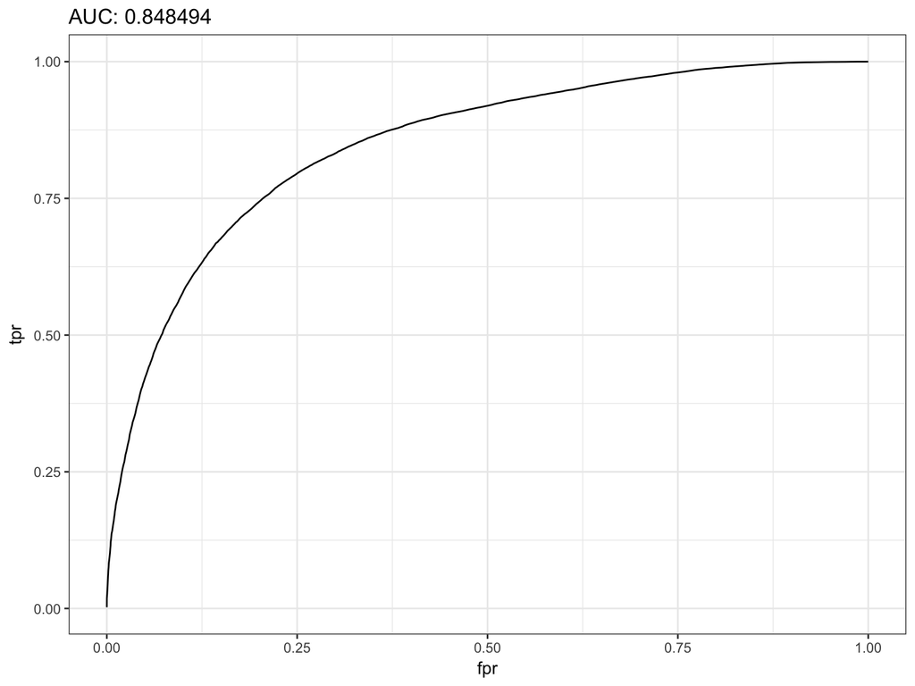

```r
# area under the curve
auc <- h2o.auc(best_model, valid = TRUE)
fpr <- h2o.fpr( h2o.performance(best_model, valid = TRUE) )[['fpr']]
tpr <- h2o.tpr( h2o.performance(best_model, valid = TRUE) )[['tpr']]
ggplot( data.table(fpr = fpr, tpr = tpr), aes(fpr, tpr) ) +
geom_line() + theme_bw() + ggtitle( sprintf('AUC: %f', auc) )
```

```r
# remember to shutdown the cluster once we're done
h2o.shutdown(prompt = FALSE)
```

```
## [1] TRUE
```

[output not shown]

```
## Packages ------------------------------------------------------------------
```

[output not shown]

# Reference

- [Youtube: H2o GLM](https://www.youtube.com/watch?v=VJPltxh5Q6Q)

Ethen Liu

2016-12-28